# Reproducible Research: Peer Assessment 1

## Introduction

The purpose of this assesment is to get familiar with tools of reproducible research, namely R Markdown and knitr-package. In order to do that some data is analysed below. Given dataset was get from a personal activity monitoring device. It consists of records for the numbers of steps taken in 5 minute intervals each day during October and November 2012.

## Loading and preprocessing the data

At first I check if file with data is unpacked and load the data.

```r
if (!file.exists("activity.csv")) {unzip("activity.zip")}

activity <- read.table ("activity.csv", sep = ',', header = TRUE)
```

So, here it is:

```r
head (activity)
```

```
##   steps       date interval
## 1    NA 2012-10-01        0
## 2    NA 2012-10-01        5
## 3    NA 2012-10-01       10
## 4    NA 2012-10-01       15
## 5    NA 2012-10-01       20
## 6    NA 2012-10-01       25
```

## What is mean total number of steps taken per day?

For now missing values are ignored. I store sums of total steps taken during each day and make histogram.

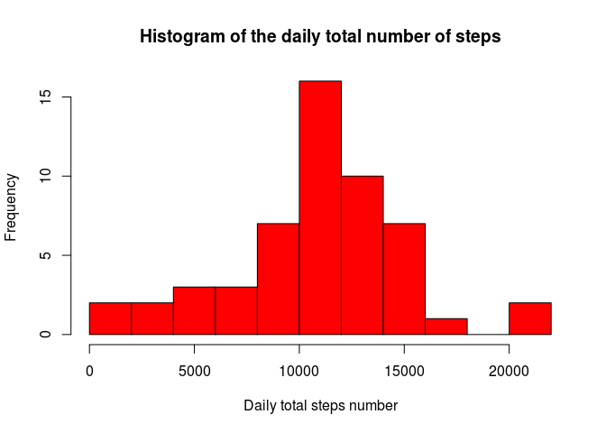

```r
steps_by_day <- aggregate (steps~date, data=activity, sum)

hist (steps_by_day$steps, main="Histogram of the daily total number of steps", xlab= "Daily total steps number", col="red", breaks = 12 )
```

Here’s the mean of total number of steps per day:

```r
mean (steps_by_day$steps)
```

```
## [1] 10766.19
```

And the median:

```r
median (steps_by_day$steps)
```

```
## [1] 10765
```

## What is the average daily activity pattern?

Here I calculate mean values for each time interval for overall period and make plot for this data. Missing values are still ignored.

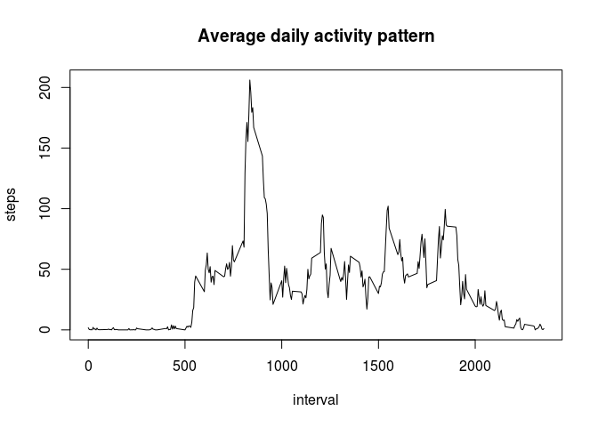

```r
day_pattern <- aggregate (steps~interval, data=activity, mean, na.rm=TRUE)

plot (day_pattern, type = "l", main = "Average daily activity pattern")
```

That’s 5-minute interval, containing the maximum number of steps on average:

```r
day_pattern$interval[which.max(day_pattern$steps)]
```

```
## [1] 835
```

## Imputing missing values

The total number of missing values in the dataset:

```r
sum(is.na(activity$steps))
```

```
## [1] 2304
```

I copy initial dataset and replace all missing values of steps with average steps number for the same time interval for all period.

```r
complete <- activity

for (i in 1:nrow(complete)){
        if (is.na(complete$steps[i])){
                complete$steps[i] <- day_pattern$steps[day_pattern$interval == complete$interval[i]]
        }
}
```

Now I make the histogram of total steps per day for the complete dataset.

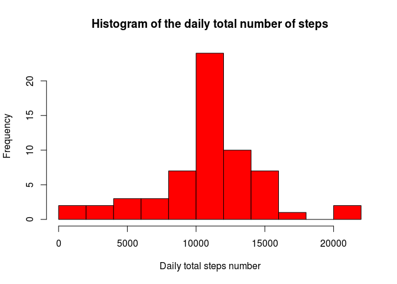

```r
steps_by_day_complete <- aggregate (steps~date, data=complete, sum)

hist (steps_by_day_complete$steps, main="Histogram of the daily total number of steps", xlab= "Daily total steps number", col="red", breaks = 12 )
```

Here is new mean value:

```r
mean (steps_by_day_complete$steps)
```

```
## [1] 10766.19
```

And new median:

```r
median (steps_by_day_complete$steps)
```

```
## [1] 10766.19
```

We can see that the mean is absolutely same and median is just slightly shifted.

## Are there differences in activity patterns between weekdays and weekends?

First I need to transform dates into appropriate format.

```r
complete$date <- as.Date(complete$date)
```

Now I can make new factor variable with type of day:

```r
complete$day <- factor(ifelse(weekdays(complete$date) %in% c('Saturday','Sunday'), 'weekend', 'weekday'), levels = c('weekend','weekday'))
```

Further I calculate means for each day and interval and make plot for different types of days.

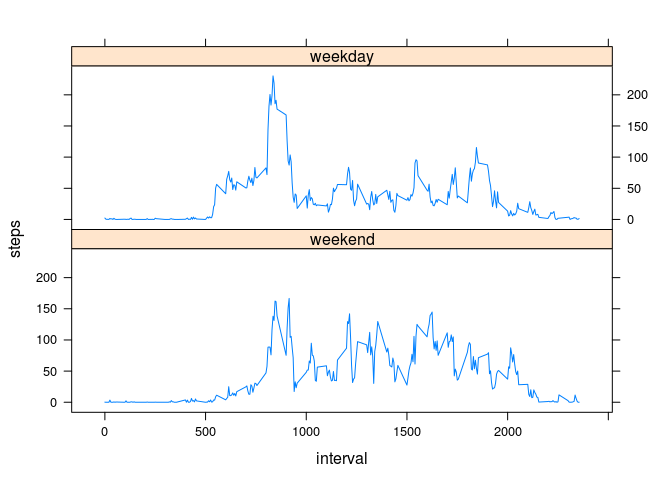

```r
pattern_by_day_type <- aggregate (steps~interval+day, data=complete, mean)

library(lattice)
xyplot(steps ~ interval|day, data = pattern_by_day_type, type = 'l', layout = c(1,2))
```